# Tarea 1 - Introducción a las Redes Neuronales y Deep Learning

**Nombre:** Bruno Morici

**ROL USM:** 202373555-8

**Curso:** INF395, Introducción a las Redes Neuronales y Deep Learning

**Profesor:** Alejandro Veloz

**Fecha:** 09/09/2025

## Introducción

En esta tarea se abordarán tres grandes bloques:

I. **Regresión lineal y regularización.**  
II. **Descubrimiento causal usando modelos VAR.**  
III. **Red neuronal feedforward.**

A continuación se presenta la organización del trabajo y los resultados obtenidos.

# Parte I: Regresión lineal y regularización

```python
%pip install ucimlrepo
%pip install scikit-learn
```

```python
import numpy as np
import pandas as pd
import matplotlib.pyplot as plt

from IPython.display import display, Math

from ucimlrepo import fetch_ucirepo
from sklearn.model_selection import train_test_split
from sklearn.linear_model import LinearRegression
from sklearn.linear_model import Lasso
```

```python
# fetch dataset
dataset = fetch_ucirepo(id=1) # abalone dataset
# metadata
print(dataset.metadata)
# variable information
print(dataset.variables)
```

```
{'uci_id': 1, 'name': 'Abalone', 'repository_url': 'https://archive.ics.uci.edu/dataset/1/abalone', 'data_url': 'https://archive.ics.uci.edu/static/public/1/data.csv', 'abstract': 'Predict the age of abalone from physical measurements', 'area': 'Biology', 'tasks': ['Classification', 'Regression'], '…
             name     role         type demographic  \
0             Sex  Feature  Categorical        None
1          Length  Feature   Continuous        None
2        Diameter  Feature   Continuous        None
3          Height  Feature   Continuous        None
4    Whole_weight  Feature   Continuous        None
5  Shucked_weight  Feature   Continuous        None
6  Viscera_weight  Feature   Continuous        None
7    Shell_weight  Feature   Continuous        None
8           Rings   Target      Integer        None

                   description  units missing_values
0         M, F, and I (infant)   None             no
1    Longest shell measurement     mm             no
2      perpendicular to length     mm             no
3           with meat in shell     mm             no
4                whole abalone  grams             no
5               weight of meat  grams             no
6  gut weight (after bleeding)  grams             no
7            after being dried  grams             no
8  +1.5 gives the age in years   None             no
```

```python
# data (as pandas dataframes)
X = dataset.data.features
y = dataset.data.targets
print(X.shape, y.shape)
```

```
(4177, 8) (4177, 1)
```

```python
X.head()
```

|  | Sex | Length | Diameter | Height | Whole_weight | Shucked_weight | Viscera_weight | Shell_weight |
| --- | --- | --- | --- | --- | --- | --- | --- | --- |
| 0 | M | 0.455 | 0.365 | 0.095 | 0.5140 | 0.2245 | 0.1010 | 0.150 |
| 1 | M | 0.350 | 0.265 | 0.090 | 0.2255 | 0.0995 | 0.0485 | 0.070 |
| 2 | F | 0.530 | 0.420 | 0.135 | 0.6770 | 0.2565 | 0.1415 | 0.210 |
| 3 | M | 0.440 | 0.365 | 0.125 | 0.5160 | 0.2155 | 0.1140 | 0.155 |
| 4 | I | 0.330 | 0.255 | 0.080 | 0.2050 | 0.0895 | 0.0395 | 0.055 |

```python
y.head()
```

|  | Rings |
| --- | --- |
| 0 | 15 |
| 1 | 7 |
| 2 | 9 |
| 3 | 10 |
| 4 | 7 |

```python
# Convert categorical 'Sex' using get_dummies()
X = pd.get_dummies(X)
X.head()
```

|  | Length | Diameter | Height | Whole_weight | Shucked_weight | Viscera_weight | Shell_weight | Sex_F | Sex_I | Sex_M |
| --- | --- | --- | --- | --- | --- | --- | --- | --- | --- | --- |
| 0 | 0.455 | 0.365 | 0.095 | 0.5140 | 0.2245 | 0.1010 | 0.150 | False | False | True |
| 1 | 0.350 | 0.265 | 0.090 | 0.2255 | 0.0995 | 0.0485 | 0.070 | False | False | True |
| 2 | 0.530 | 0.420 | 0.135 | 0.6770 | 0.2565 | 0.1415 | 0.210 | True | False | False |
| 3 | 0.440 | 0.365 | 0.125 | 0.5160 | 0.2155 | 0.1140 | 0.155 | False | False | True |
| 4 | 0.330 | 0.255 | 0.080 | 0.2050 | 0.0895 | 0.0395 | 0.055 | False | True | False |

```python
# Convert to numpy arrays
X_np = X.to_numpy().astype('float')
y_np = y.to_numpy().flatten()

# Split into train and test sets
X_train, X_test, y_train, y_test = train_test_split(X_np, y_np, test_size=0.2, random_state=42)
X_train, X_val, y_train, y_val = train_test_split(X_train, y_train, test_size=0.2, random_state=42)

print(f'Samples for training: {X_train.shape[0]}')
print(f'Samples for validation: {X_val.shape[0]}')
print(f'Samples for testing: {X_test.shape[0]}')
```

```
Samples for training: 2672
Samples for validation: 669
Samples for testing: 836
```

```python
# Fit regression model
model = LinearRegression()
model.fit(X_train, y_train) # Entrena el modelo

# Evaluate
score = model.score(X_test, y_test) # Que porcentaje de la variabilidad de los datos es explicada por el modelo entrenado
print(f"Test R^2: {score:.3f}")
print("Coefficients:", model.coef_) # Coeficientes o theta's del entrenamiento, es decir, no de la solucion analitica
```

```
Test R^2: 0.545
Coefficients: [ -1.02217201   8.83603361  24.35454601   8.94974547 -20.65659391
  -9.05850108   7.59042072   0.19513526  -0.50004446   0.3049092 ]
```

```python
# Obtenemos numero de muestras de cada conjunto (entrenamiento, validacion y testeo)
N_train = X_train.shape[0]
N_val = X_val.shape[0]
N_test = X_test.shape[0]

theta = np.random.rand(X_train.shape[1]) # Inicializamos los pesos de la regresion de forma aleatoria
eta = 1e-5 # Tasa de aprendizaje para el descenso de gradiente
nepochs = 10000 # Numero de iteraciones del entrenamiento

# Definimos los errores cuadraticos medios
mse_train = []
mse_val = []

# Iteramos para entrenar
for epoch in range(nepochs + 1):
    # Actualizamos theta haciendo uso del descenso de gradiente
    # OBS: Descenso de gradiente estocástico (sin sumatoria) (diapositiva 18 de modelos lineales)
    theta = theta + eta * X_train.T @ (y_train - X_train @ theta) # OBS: el @ es producto de matrices

    # Calculamos los ECM y los ponemos en las listas
    mse_train.append((1/N_train) * np.linalg.norm(y_train - X_train @ theta)**2)
    mse_val.append((1/N_val) * np.linalg.norm(y_val - X_val @ theta)**2)

# Solucion analitica
# OBS: Si derivamos el ECM y lo igualamos a cero, se obtiene una formula con el vector X y el vector THETA, de ahi se puede despejar THETA obteniendo una solucion analitica

# Fórmula de la solución analítica de mínimos cuadrados
display(Math(r'\theta = (X^T X)^{-1} X^T y'))

theta_analytical = np.linalg.inv(X_train.T @ X_train) @ X_train.T @ y_train
print(theta_analytical)
mse_analytical_train = (1/N_train) * np.linalg.norm(y_train - X_train @ theta_analytical)**2
mse_analytical_val = (1/N_val) * np.linalg.norm(y_val - X_val @ theta_analytical)**2
```

$\displaystyle \theta = (X^T X)^{-1} X^T y$

```
[ -1.02217201   8.83603361  24.35454601   8.94974547 -20.65659391
  -9.05850108   7.59042072   3.52040712   2.8252274    3.63018107]
```

Nota: La solución analítica (theta_analytical) y la solución de coeficientes al ajustar la Regresión Lineal deberían dar la misma solución, ya que se trabaja sobre el mismo conjunto de datos de entrenamiento.

Podría haber variación debido a ignorar el bias en la solución analítica

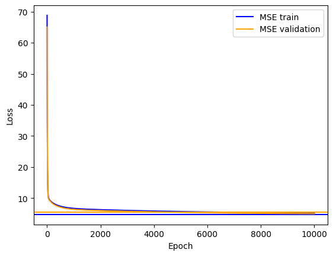

```python
# Hacemos un grafico mostrando como el Error va disminuyendo en cada iteracion tanto para entrenamiento como para validacion
plt.plot(mse_train, label='MSE train', color='blue')
plt.axhline(y=mse_analytical_train, xmin=0, xmax=1, color='blue')
plt.plot(mse_val, label='MSE validation', color='orange')
plt.axhline(y=mse_analytical_val, xmin=0, xmax=1, color='orange')
plt.xlabel('Epoch')
plt.ylabel('Loss')
plt.legend()
plt.show()
```

### Implementación de Lasso para determinar importancia de las variables

```python
# Formula del error de datos + regularizacion
display(Math(r'E(\theta) = \frac{1}{2N} \sum_{i=1}^{N} \Big(y_i - \sum_{j=1}^{d} X_{ij} \theta_j \Big)^2 + \alpha \sum_{j=1}^{d} |\theta_j|'))

# Formula de minimo error de datos y minimo error de regularizacion (la derivada de la anterior)
## Esta se usa en la implemetacion de forma directa
display(Math(r'\theta^{(k+1)} = \theta^{(k)} + \frac{\eta}{N} X^T (Y - X \theta^{(k)}) - \eta \, \alpha \, \mathrm{sign}(\theta^{(k)})'))
```

$\displaystyle E(\theta) = \frac{1}{2N} \sum_{i=1}^{N} \Big(y_i - \sum_{j=1}^{d} X_{ij} \theta_j \Big)^2 + \alpha \sum_{j=1}^{d} |\theta_j|$

$\displaystyle \theta^{(k+1)} = \theta^{(k)} + \frac{\eta}{N} X^T (Y - X \theta^{(k)}) - \eta \, \alpha \, \mathrm{sign}(\theta^{(k)})$

```python
# Creacion propia de Lasso
class MyLasso():
    # Constructor
    def __init__(self, alpha=0.1, eta=1e-5, n_epochs=10000):
        self.alpha = alpha      # lambda de regularización
        self.eta = eta          # tasa de aprendizaje
        self.n_epochs = n_epochs

    # OBS: Debido a la funcion valor absoluto presente en Lasso, no es diferenciable en 0 para theta, resolvemos eso con np.sign()

    # Resolvemos modelo mediante iteraciones, tal como hacen al sacar solucion analitica previamente
    def fit(self, X, Y):
        N = X.shape[0]
        d = X.shape[1]

        self.coef_ = np.random.rand(d) # Inicializamos los coeficientes de forma aleatoria

        # Iteramos para entrenar, minimizando el error de los coeficientes
        for _ in range(self.n_epochs + 1):
            data_term = (self.eta/N) * X.T @ (Y - X @ self.coef_)
            regularization_term = self.eta * self.alpha * np.sign(self.coef_)
            self.coef_ += data_term - regularization_term # Formula mencionada anteriormente

        return self

    # Funcion que retorna resultados de las predicciones
    # Recibe una matriz de features y la multiplica por los coeficientes, entregando una prediccion (target)
    def predict(self, X):
        return X @ self.coef_
```

```python
# Lasso de SKLearn
lasso_model = Lasso(alpha=0.1)
lasso_model.fit(X_train, y_train)

# Implementacion propia
my_lasso_model = MyLasso(alpha=0.1)
my_lasso_model.fit(X_train, y_train)

# Coeficientes
coef_sklearn = lasso_model.coef_
coef_my = my_lasso_model.coef_

# Crear DataFrame comparativo
df = pd.DataFrame({
    "Variable": [f"X{i}" for i in range(len(coef_sklearn))],
    "Coef_sklearn": coef_sklearn,
    "Importancia_sklearn": np.abs(coef_sklearn),
    "Coef_MyLasso": coef_my,
    "Importancia_MyLasso": np.abs(coef_my)
})

df # Mostramos
```

|  | Variable | Coef_sklearn | Importancia_sklearn | Coef_MyLasso | Importancia_MyLasso |
| --- | --- | --- | --- | --- | --- |
| 0 | X0 | 0.000000 | 0.000000 | 1.280296 | 1.280296 |
| 1 | X1 | 0.000000 | 0.000000 | 0.911929 | 0.911929 |
| 2 | X2 | 0.000000 | 0.000000 | 0.986309 | 0.986309 |
| 3 | X3 | 2.617422 | 2.617422 | 1.489362 | 1.489362 |
| 4 | X4 | -0.000000 | 0.000000 | 1.033184 | 1.033184 |
| 5 | X5 | 0.000000 | 0.000000 | 1.075890 | 1.075890 |
| 6 | X6 | 0.000000 | 0.000000 | 1.075393 | 1.075393 |
| 7 | X7 | 0.013899 | 0.013899 | 0.874670 | 0.874670 |
| 8 | X8 | -0.961786 | 0.961786 | 0.251278 | 0.251278 |
| 9 | X9 | 0.000000 | 0.000000 | 0.460265 | 0.460265 |

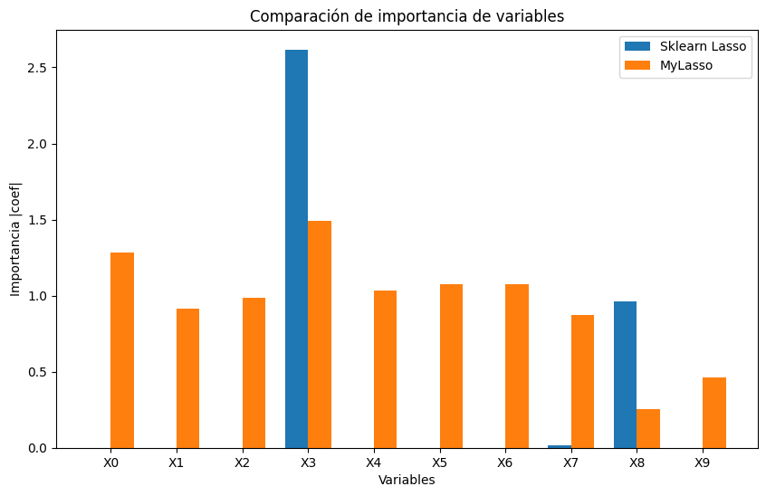

```python
# Variables
vars = df['Variable']
x = np.arange(len(vars))

# Ancho de las barras
width = 0.35

# Gráfico comparativo de importancia (valor absoluto)
fig, ax = plt.subplots(figsize=(10,6))
ax.bar(x - width/2, df['Importancia_sklearn'], width, label='Sklearn Lasso')
ax.bar(x + width/2, df['Importancia_MyLasso'], width, label='MyLasso')

ax.set_xlabel('Variables')
ax.set_ylabel('Importancia |coef|')
ax.set_title('Comparación de importancia de variables')
ax.set_xticks(x)
ax.set_xticklabels(vars)
ax.legend()
plt.show()
```

# Parte II: Descubrimiento causal usando modelos VAR

```python
import numpy as np
import matplotlib.pyplot as plt
from sklearn.linear_model import LinearRegression, Lasso, Ridge
```

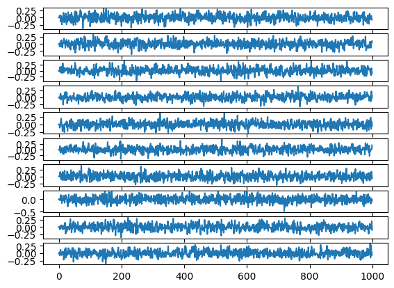

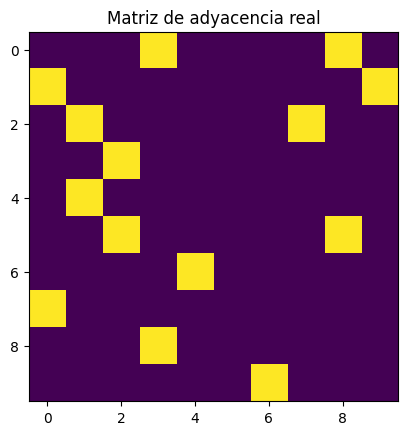

```python
# --- Parametros del modelo ---
N = 1000
N_nds = 10
p = 3
X = np.zeros((N, N_nds))
A = np.zeros((N_nds, N_nds, p))

# --- Matriz de conexiones ---
conexiones = np.zeros((N_nds, N_nds))
conexiones[0, 3] = 1
conexiones[1, 0] = 1
conexiones[2, 1] = 1
conexiones[3, 2] = 1
conexiones[4, 1] = 1
conexiones[5, 8] = 1
conexiones[7, 0] = 1
conexiones[9, 6] = 1
conexiones[2, 7] = 1
conexiones[8, 3] = 1
conexiones[6, 4] = 1
conexiones[1, 9] = 1
conexiones[5, 2] = 1
conexiones[0, 8] = 1

# --- Generacion de coeficientes A segun la matriz de conexiones ---
std_mattrans = 0.2
for j in range(p):
    for i in range(N_nds):
        for k in range(N_nds):
            if conexiones[i, k] == 1:
                A[i, k, j] = std_mattrans * np.random.randn()

# --- Generacion de los datos segun el modelo VAR ---
std_datos = 0.1
for t in range(p, N):
    X[t, :] = std_datos * np.random.randn(N_nds) # Inicializacion en cero
    for j in range(p):
        X[t, :] += A[:, :, j] @ X[t-j-1, :] # Entrenamiento con VAR

# --- Visualizacion de las series ---
fig, axs = plt.subplots(nrows = N_nds, ncols = 1)
for nd in range(N_nds):
    axs[ nd ].plot( X[:, nd] )
plt.show()

# --- Matriz de adyacencia real (1 si hay conexion) ---
A_ = np.sum(A, axis=2)
A_[A_ != 0] = 1
plt.imshow(A_)
plt.title("Matriz de adyacencia real")
plt.show()
```

```python
# Construimos las matrices X_lag (inputs) y Y (targets).

# Y contiene los valores actuales (desde el tiempo p)
Y = X[p:, :]

# X_lag contendra los valores pasados concatenados (lag1|lag2|lag3)
X_lag = []
for lag in range(1, p + 1):
    X_lag.append(X[p - lag:N - lag, :])
X_lag = np.hstack(X_lag)

# Normalizamos las variables (media 0, varianza 1)
# Esto ayuda a que Lasso y Ridge se comporten correctamente
X_lag = (X_lag - np.mean(X_lag, axis=0)) / np.std(X_lag, axis=0)
Y = (Y - np.mean(Y, axis=0)) / np.std(Y, axis=0)

print("Dimensión de X_lag:", X_lag.shape)
print("Dimensión de Y:", Y.shape)
```

```
Dimensión de X_lag: (997, 30)
Dimensión de Y: (997, 10)
```

```python
# Vamos a estimar los coeficientes para cada nodo usando: OLS, Lasso, Ridge

metodos = {
    "OLS": LinearRegression(fit_intercept=False),
    "Lasso": Lasso(alpha=0.05, fit_intercept=False, max_iter=10000),
    "Ridge": Ridge(alpha=0.05, fit_intercept=False)
}

A_estimadas = {}

for nombre, modelo in metodos.items():
    print(f"\nEstimando conexiones con {nombre}...")
    A_est = np.zeros((N_nds, X_lag.shape[1]))

    for i in range(N_nds):
        modelo.fit(X_lag, Y[:, i])
        A_est[i, :] = modelo.coef_

    # Normalizamos la matriz por nodo para mejorar deteccion de conexiones
    A_est = A_est / (np.max(np.abs(A_est)) + 1e-9)

    A_estimadas[nombre] = A_est
    print(f"{nombre} completado.")
```

```
Estimando conexiones con OLS...
OLS completado.

Estimando conexiones con Lasso...
Lasso completado.

Estimando conexiones con Ridge...
Ridge completado.
```

```
--- OLS ---
Precisión: 0.13
Recall: 0.50
F1-score: 0.20
```

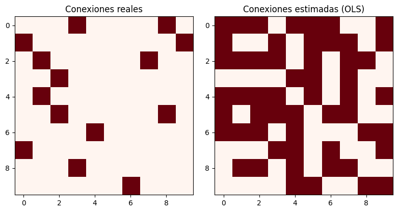

```
--- Lasso ---
Precisión: 0.15
Recall: 0.21
F1-score: 0.18
```

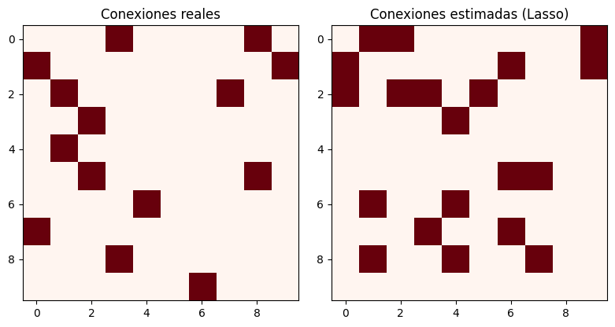

```
--- Ridge ---
Precisión: 0.13
Recall: 0.50
F1-score: 0.20
```

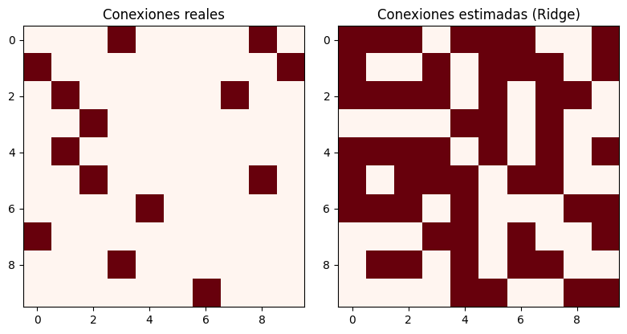

```python
umbral = 0.2

# Convertimos A_real de conexiones a forma 2D (aplanamos matriz)
A_real = np.sum(A, axis=2)
A_real[A_real != 0] = 1

for nombre, A_est in A_estimadas.items():
    # Reshape a 3D para sumar sobre los lags
    A_est_reshaped = A_est.reshape(N_nds, N_nds, p)
    A_hat = (np.sum(np.abs(A_est_reshaped), axis=2) > umbral).astype(int)

    # Metricas básicas
    TP = np.sum((A_hat == 1) & (A_real == 1))
    FP = np.sum((A_hat == 1) & (A_real == 0))
    FN = np.sum((A_hat == 0) & (A_real == 1))

    precision = TP / (TP + FP + 1e-9)
    recall = TP / (TP + FN + 1e-9)
    f1 = 2 * precision * recall / (precision + recall + 1e-9)

    print(f"\n--- {nombre} ---")
    print(f"Precisión: {precision:.2f}")
    print(f"Recall: {recall:.2f}")
    print(f"F1-score: {f1:.2f}")

    # Visualizacion lado a lado
    plt.figure(figsize=(8,4))
    plt.subplot(1,2,1)
    plt.title("Conexiones reales")
    plt.imshow(A_real, cmap='Reds', origin='upper', vmin=0, vmax=1)
    plt.subplot(1,2,2)
    plt.title(f"Conexiones estimadas ({nombre})")
    plt.imshow(A_hat, cmap='Reds', origin='upper', vmin=0, vmax=1)
    plt.tight_layout()
    plt.show()
```

### II. Causal discovery con el modelo VAR

Se consideró un modelo VAR para un vector de 10 nodos ($N_{nds} = 10$) con 3 rezagos ($p = 3$):

$$ X_t = \sum_{j=1}^{p} A_j X_{t-j} + \varepsilon_t $$

donde $A_j$ es la matriz de coeficientes en el rezago $j$ y $\varepsilon_t$ es ruido blanco.

Se generaron datos sintéticos para 10 nodos con algunas conexiones fijas entre ellos. A partir de estas series, se estimaron las matrices de adyacencia usando:

- **OLS** (mínimos cuadrados sin regularización)
- **Lasso** (regularización L1)
- **Ridge** (regularización L2)

Se evaluó el desempeño de cada método utilizando **precisión, recall y F1-score**, considerando como predicción correcta la detección de una conexión real.

### Resultados - Parte II

#### Efecto de la regularización

Se observa empíricamente que la regularización tiene un efecto importante sobre la detección de conexiones. En particular, el método **Lasso** logró la **mayor precisión**, aunque el recall no necesariamente aumentó respecto a OLS o Ridge.

[output not shown]

**Interpretación:**

- **OLS:** detecta muchas conexiones reales (recall alto) pero también genera falsos positivos, lo que reduce la precisión.
- **Lasso:** reduce falsos positivos (mejor precisión), aunque detecta menos conexiones reales (recall menor).
- **Ridge:** comportamiento similar a OLS, con poca ganancia en precisión.

Visualmente, comparando las matrices de adyacencia real y estimadas, se puede ver que Lasso produce una **estimación más esparcida y selectiva**, mientras que OLS y Ridge tienden a detectar más conexiones falsas.

# Parte III: Red neuronal feedfordward

## Parte III — Ítem (1)

Dada una red neuronal con múltiples capas neuronales y múltiples neuronas en cada capa, el algoritmo de **Backpropagation** permite reducir la función de error ajustando los pesos de cada neurona.

Este proceso se realiza mediante una **derivación parcial** del error en la **última capa de neuronas**.  
Ese error se **propaga hacia las capas previas**, debido a que esta red se construye “alimentando” cada capa con la información de la capa anterior.

Luego de ello, se iguala a cero la derivada para **minimizar el error** y se **actualizan los pesos**, enviando esa actualización hacia adelante otra vez, terminando nuevamente en la capa final (capa ( L )).

### Función de activación de una neurona

La ecuación general de la función de activación ( \sigma ) de una neurona es:

$$ \sigma(z) = \sigma\left( \sum_{j=1}^{n} x_j w_j + w_0 \right) $$

donde:

- $x_j$ son las entradas a la neurona,
- $w_j$ son los pesos,
- $w_0$ es el sesgo (bias),
- y $\sigma{(z)}$ es la función de activación (por ejemplo, ReLU o LeakyReLU).

### Salida de una capa $l$

La salida de cualquier capa $l$ se calcula como:

$$ a^{(l)} = \sigma^{(l)}(W^{(l)} a^{(l-1)} + w_0^{(l)}) $$

### Función de costo

La función costo general utilizada para entrenar la red es:

$$ J(W, w_0) = \sum_{d=1}^{D} \text{loss}(\text{NN}(x_d; W, w_0), Y_d) $$

### Derivada de la función de costo en la última capa

En la **última capa $L$**, la derivada de la función de costo respecto a la activación $a^{(L)}$ viene dada por:

$$ \frac{\partial J}{\partial z^{(L)}} = a^{(L)} - y $$

y el gradiente de los pesos en esa capa se obtiene como:

$$ \frac{\partial J}{\partial W^{(L)}} = (a^{(L)} - y) \cdot (a^{(L-1)})^T $$

### Propagación hacia capas previas

El error se propaga hacia atrás según:

$$ \delta^{(l)} = ((W^{(l+1)})^T \delta^{(l+1)}) \odot \sigma'^{(l)}(z^{(l)}) $$

donde:

- $\delta^{(l)}$ representa el error en la capa $l$,
- $\odot$ denota el producto elemento a elemento,
- $\sigma'^{(l)}$ es la derivada de la función de activación en la capa $l$.

### Función de clasificación

Para resolver este problema, usaremos la función SoftMax, ya que entrega resultados probabilísticos lo que hace mas acertado el resultado:

$$ \text{Softmax}(z_i) = \frac{e^{z_i}}{\sum_{j=1}^{K} e^{z_j}} $$

donde:

- $z_i$ es la entrada de la neurona $i$ en la capa de salida,
- $K$ es el número total de clases,
- $\text{Softmax}(z_i)$ representa la probabilidad predicha de la clase $i$.

Estas ecuaciones permiten implementar el **entrenamiento de la red neuronal feedforward** mediante el algoritmo de **backpropagation**, ajustando los pesos $W$ y sesgos $w_0$ para minimizar el error global $J(W, w_0)$.

## Parte III — Ítem (2)

Dadas las fórmulas mencionadas anteriormente, resolveremos el problema de clasificación con la red FeedForward.

```
8
```

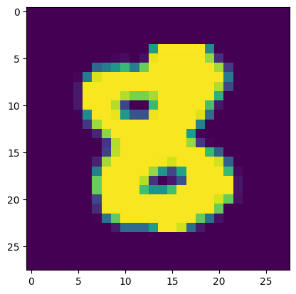

```python
import numpy as np
import matplotlib.pyplot as plt
from sklearn.model_selection import train_test_split
import matplotlib.pyplot as plt

def load_idx_images(path):
    with open(path,'rb') as f:
        data = np.frombuffer(f.read(), dtype=np.uint8)
    return data[16:].reshape(-1, 28*28) / 255.0

def load_idx_labels(path):
    with open(path,'rb') as f:
        data = np.frombuffer(f.read(), dtype=np.uint8)
    return data[8:]

X_full = load_idx_images('mnist/train-images.idx3-ubyte')
y_full = load_idx_labels('mnist/train-labels.idx1-ubyte')
X_test = load_idx_images('mnist/t10k-images.idx3-ubyte')
y_test = load_idx_labels('mnist/t10k-labels.idx1-ubyte')

# Division de datos
X_train, X_val, y_train, y_val = train_test_split(X_full, y_full, test_size=10000, random_state=42)

# Mostramos la forma del conjunto de entrenamiento (se muestra un digito ("8") escrito a mano)
im = X_train[10000, :].reshape(28,28)
print(y_train[10000])
plt.imshow(im)
plt.show()
```

```python
# ReLU y LeakyReLU
def relu(z):
    return np.maximum(0, z)

def relu_derivative(z):
    return (z > 0).astype(float)

def leaky_relu(z, alpha=0.01):
    return np.where(z > 0, z, alpha*z)

def leaky_relu_derivative(z, alpha=0.01):
    dz = np.ones_like(z)
    dz[z < 0] = alpha
    return dz

# Softmax para salida
def softmax(z):
    exps = np.exp(z - np.max(z, axis=0, keepdims=True))  # restamos max para estabilidad numerica
    return exps / np.sum(exps, axis=0, keepdims=True)
```

```python
# ===============================
# HIPERPARAMETROS
# ===============================
input_size = 28*28
output_size = 10
hidden_layers = [128] # capas ocultas
learning_rate = 0.05
activation = 'leaky' # 'relu' o 'leaky'
epochs = 10
batch_size = 64

layer_sizes = [input_size] + hidden_layers + [output_size]
```

```python
# ===============================
# CLASE DE LA RED NEURONAL
# ===============================
class FeedforwardNN:
    def __init__(self, layer_sizes, activation='relu', lr=0.01):
        self.layer_sizes = layer_sizes
        self.num_layers = len(layer_sizes)
        self.lr = lr
        self.activation_name = activation
        self.weights = []
        self.biases = []
        for i in range(1, self.num_layers):
            self.weights.append(np.random.randn(layer_sizes[i], layer_sizes[i-1])*0.01)
            self.biases.append(np.zeros((layer_sizes[i],1)))

    def activate(self, z):
        if self.activation_name=='relu':
            return relu(z)
        else:
            return leaky_relu(z)

    def activate_derivative(self, z):
        if self.activation_name=='relu':
            return relu_derivative(z)
        else:
            return leaky_relu_derivative(z)

    # ===============================
    # FEEDFORWARD
    # ===============================
    def forward(self, x):
        a = x.T  # columnas = muestras
        activations = [a]
        zs = []
        for i in range(self.num_layers-2):
            z = self.weights[i] @ a + self.biases[i]
            zs.append(z)
            a = self.activate(z)
            activations.append(a)
        # capa salida
        zL = self.weights[-1] @ a + self.biases[-1]
        zs.append(zL)
        aL = softmax(zL)
        activations.append(aL)
        return activations, zs

    # ===============================
    # BACKPROPAGATION
    # ===============================
    def backward(self, x, y):
        m = x.shape[0]
        activations, zs = self.forward(x)
        grads_w = [np.zeros_like(w) for w in self.weights]
        grads_b = [np.zeros_like(b) for b in self.biases]

        # convertir y a one-hot
        y_onehot = np.zeros((self.layer_sizes[-1], m))
        y_onehot[y, np.arange(m)] = 1

        # delta ultima capa
        delta = activations[-1] - y_onehot
        grads_w[-1] = delta @ activations[-2].T / m
        grads_b[-1] = np.sum(delta, axis=1, keepdims=True) / m

        # delta capas previas
        for l in range(self.num_layers-3, -1, -1):
            delta = (self.weights[l+1].T @ delta) * self.activate_derivative(zs[l])
            grads_w[l] = delta @ activations[l].T / m
            grads_b[l] = np.sum(delta, axis=1, keepdims=True) / m

        # actualizar pesos
        for i in range(self.num_layers-1):
            self.weights[i] -= self.lr * grads_w[i]
            self.biases[i] -= self.lr * grads_b[i]

    # ===============================
    # ENTRENAMIENTO
    # ===============================
    def train(self, X, y, epochs=5, batch_size=64, X_val=None, y_val=None):
        n = X.shape[0]
        for e in range(epochs):
            idx = np.random.permutation(n)
            X, y = X[idx], y[idx]
            for i in range(0, n, batch_size):
                xb = X[i:i+batch_size]
                yb = y[i:i+batch_size]
                self.backward(xb, yb)
            if X_val is not None:
                acc = self.accuracy(X_val, y_val)
                print(f'Epoch {e+1}/{epochs} - Val Accuracy: {acc:.4f}')

    # ===============================
    # PREDICCION
    # ===============================
    def predict(self, X):
        activations, _ = self.forward(X)
        return np.argmax(activations[-1], axis=0)

    # ===============================
    # EXACTITUD
    # ===============================
    def accuracy(self, X, y):
        y_pred = self.predict(X)
        return np.mean(y_pred == y)
```

```python
# ===============================
# CREAR MODELO Y ENTRENAR
# ===============================
nn = FeedforwardNN(layer_sizes, activation=activation, lr=learning_rate)
nn.train(X_train, y_train, epochs=epochs, batch_size=batch_size, X_val=X_val, y_val=y_val)

# evaluar en test
acc_test = nn.accuracy(X_test, y_test)
print(f'Exactitud en test set: {acc_test:.4f}')
```

```
Exactitud en test set: 0.9578
```

Aquí dejo un ejemplo de una predicción real sobre el y_test, se puede ver que al hacer variar los hiperparámetros, la predicción del número cambia.

Variar "index" para cambiar de ejemplos

```
Prediccion de la red: 6
Digito real: 6
```

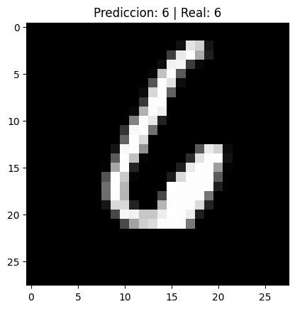

```python
# ===============================
# PREDICCION DE UN DIGITO ESPECIFICO
# ===============================
index = 1990 # cambia este indice para ver otro ejemplo
sample = X_test[index].reshape(1,-1)
predicted_digit = nn.predict(sample)[0]
real_digit = y_test[index]

print(f'Prediccion de la red: {predicted_digit}')
print(f'Digito real: {real_digit}')

# mostrar imagen
plt.imshow(sample.reshape(28,28), cmap='gray')
plt.title(f'Prediccion: {predicted_digit} | Real: {real_digit}')
plt.show()
```

## Parte III — Ítem (3)

Probaré múltiples modelos con diferentes hiperparámetros para ver cual es el mejor modelo con un Cross Validation de 10 divisiones.

```python
from sklearn.model_selection import KFold
import itertools

# ==============================
# Hiperparametros a probar
# ==============================
learning_rates = [0.01, 0.05]
activations = ['relu', 'leaky']
hidden_layers_list = [[64], [128], [128,64]]
epochs_list = [5, 10]
batch_size = 64

# ==============================
# K-Fold Cross-Validation
# ==============================
k_folds = 10 # Cantidad de divisiones para el Cross Validation
kf = KFold(n_splits=k_folds, shuffle=True, random_state=42)

# ==============================
# Guardar resultados
# ==============================
resultados = []

# ==============================
# Combinaciones de hiperparametros
# ==============================
for lr, act, hidden, ep in itertools.product(learning_rates, activations, hidden_layers_list, epochs_list):
    accs = []
    for train_idx, val_idx in kf.split(X_train):
        # Dividir en train/validation
        X_tr, X_val_cv = X_train[train_idx], X_train[val_idx]
        y_tr, y_val_cv = y_train[train_idx], y_train[val_idx]

        # Crear red nueva
        layer_sizes_cv = [input_size] + hidden + [output_size]
        nn_cv = FeedforwardNN(layer_sizes_cv, activation=act, lr=lr)

        # Entrenar
        nn_cv.train(X_tr, y_tr, epochs=ep, batch_size=batch_size)

        # Validar
        acc = nn_cv.accuracy(X_val_cv, y_val_cv)
        accs.append(acc)

    acc_promedio = np.mean(accs)
    resultados.append({
        "lr": lr,
        "activation": act,
        "hidden_layers": hidden,
        "epochs": ep,
        "val_accuracy": acc_promedio
    })
    print(f"lr={lr}, activation={act}, hidden={hidden}, epochs={ep} -> Val Accuracy={acc_promedio:.4f}")

# ==============================
# Seleccionar mejor modelo
# ==============================
mejor_modelo = max(resultados, key=lambda x: x['val_accuracy'])
print("\n✅ Mejor modelo encontrado:")
print(mejor_modelo)
```

```
lr=0.01, activation=relu, hidden=[64], epochs=5 -> Val Accuracy=0.8906
lr=0.01, activation=relu, hidden=[64], epochs=10 -> Val Accuracy=0.9078
lr=0.01, activation=relu, hidden=[128], epochs=5 -> Val Accuracy=0.8928
lr=0.01, activation=relu, hidden=[128], epochs=10 -> Val Accuracy=0.9104
lr=0.01, activation=relu, hidden=[128, 64], epochs=5 -> Val Accuracy=0.3646
lr=0.01, activation=relu, hidden=[128, 64], epochs=10 -> Val Accuracy=0.8398
lr=0.01, activation=leaky, hidden=[64], epochs=5 -> Val Accuracy=0.8898
lr=0.01, activation=leaky, hidden=[64], epochs=10 -> Val Accuracy=0.9089
lr=0.01, activation=leaky, hidden=[128], epochs=5 -> Val Accuracy=0.8931
lr=0.01, activation=leaky, hidden=[128], epochs=10 -> Val Accuracy=0.9105
lr=0.01, activation=leaky, hidden=[128, 64], epochs=5 -> Val Accuracy=0.3798
lr=0.01, activation=leaky, hidden=[128, 64], epochs=10 -> Val Accuracy=0.8412
lr=0.05, activation=relu, hidden=[64], epochs=5 -> Val Accuracy=0.9314
lr=0.05, activation=relu, hidden=[64], epochs=10 -> Val Accuracy=0.9520
lr=0.05, activation=relu, hidden=[128], epochs=5 -> Val Accuracy=0.9292
lr=0.05, activation=relu, hidden=[128], epochs=10 -> Val Accuracy=0.9549
lr=0.05, activation=relu, hidden=[128, 64], epochs=5 -> Val Accuracy=0.9147
lr=0.05, activation=relu, hidden=[128, 64], epochs=10 -> Val Accuracy=0.9369
lr=0.05, activation=leaky, hidden=[64], epochs=5 -> Val Accuracy=0.9321
lr=0.05, activation=leaky, hidden=[64], epochs=10 -> Val Accuracy=0.9497
lr=0.05, activation=leaky, hidden=[128], epochs=5 -> Val Accuracy=0.9322
lr=0.05, activation=leaky, hidden=[128], epochs=10 -> Val Accuracy=0.9547
lr=0.05, activation=leaky, hidden=[128, 64], epochs=5 -> Val Accuracy=0.9194
lr=0.05, activation=leaky, hidden=[128, 64], epochs=10 -> Val Accuracy=0.9568

✅ Mejor modelo encontrado:
{'lr': 0.05, 'activation': 'leaky', 'hidden_layers': [128, 64], 'epochs': 10, 'val_accuracy': 0.95678}
```

### Resultados - Ítem (3)

#### Modelo

- Tasa de aprendizaje (Learning Rate): 0.05
- Función de activación: Leaky ReLU
- Cantidad de capas ocultas: 2
- Cantidad de nodos en cada capa respectivamente: 128, 64
- Número de entrenamientos (Iteraciones de Backpropagation): 10
- Precisión: 0.95678 (95.678%)

#### Observaciones

##### Learning rate

- Con lr=0.05 la red aprende mucho mejor que con lr=0.01.
- Un learning rate bajo hace que las redes profundas o con más capas no entrenen bien.

##### Número de capas y neuronas

- Una sola capa oculta de 64 o 128 neuronas funciona muy bien.
- Agregar una segunda capa ([128,64]) solo mejora si el learning rate es suficientemente alto; con lr bajo estas configuraciones fallan.

##### Función de activación

- LeakyReLU en general da resultados un poco mejores que ReLU en configuraciones profundas.
- Para capas simples, ambos funcionan casi igual.

##### Épocas

- Más épocas (10 vs 5) siempre mejora la precisión.
- Para el mejor desempeño conviene entrenar más tiempo, especialmente con lr alto y redes profundas.

##### Regla general

- No siempre más capas o más neuronas significan mejor resultado; es importante combinar correctamente learning rate, cantidad de capas y neuronas.
- Para este dataset, una o dos capas con tamaño moderado y lr=0.05 dan las mejores accuracies (~0.95–0.96).